# Coding 1 Team Project

Team Hong Kong (Maryam, Fatima, Hassan, Oszkar)

11/7/2021

## Introduction

A [data collection survey](https://raw.githubusercontent.com/maryamkhan1120/Coding-1-Hong-Kong/main/HongKong%20_Data.csv) was conducted to collect data about products from multiple shops located across two districts of Budapest. The next segment displays the mean, median and standard deviation (among other descriptive statistic measures) of the price of the two products.

## Data

Products chosen for the survey were Coca Cola (0.5 L) and Orbit gum. The main variable examined in this report is the price of the products per district.

The data was collected in person by the team.

Descriptive statistics prices

| District |  | Mean | Median | SD | Max | Min | N | range_df | P5 | P25 | P75 | P95 |
| --- | --- | --- | --- | --- | --- | --- | --- | --- | --- | --- | --- | --- |
| 9 | Orbit | 168.00 | 165.00 | 38.82 | 260.00 | 120.00 | 10 | 140.00 | 124.50 | 150.00 | 177.50 | 228.50 |
| 10 | Orbit | 179.60 | 174.00 | 50.04 | 299.00 | 129.00 | 10 | 170.00 | 129.45 | 146.25 | 198.75 | 254.45 |
| 9 | Coke | 270.50 | 260.00 | 33.04 | 340.00 | 220.00 | 10 | 120.00 | 233.50 | 252.50 | 286.25 | 322.00 |
| 10 | Coke | 291.90 | 284.50 | 64.13 | 439.00 | 219.00 | 10 | 220.00 | 219.00 | 259.00 | 316.25 | 389.95 |

Data are available from: Please refer to link in the introduction

The number of observations is 20 for all of our key variables.

### Data cleaning

Part of the data cleaning steps were changing the column names, removing the ID column and converting the district to a factor variable.

## Price distribution

The following histograms show the price distribution for each product per district.

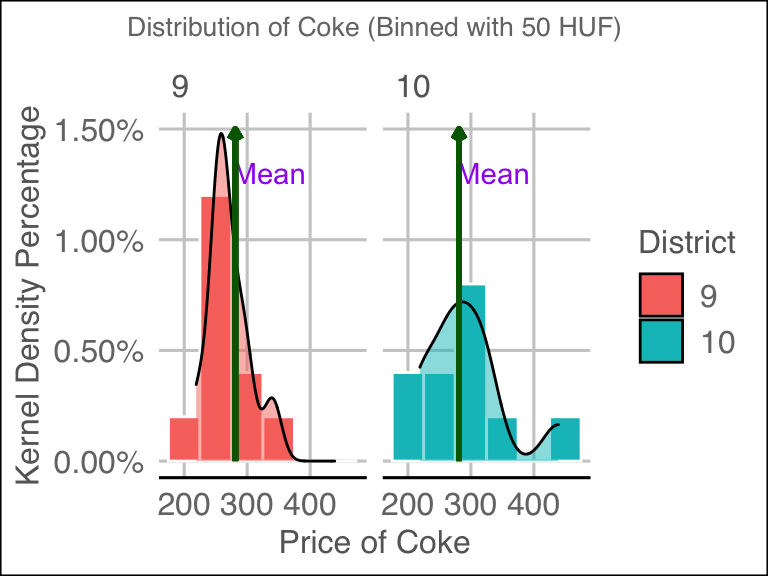

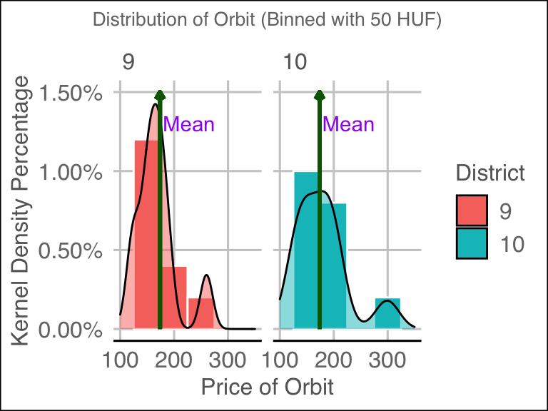

We chose 50 HUF binwidth as it is a good aggregation of the individual measurements at this pricerange.